# Hoja de trabajo 3 - Árboles de decisión

Josué Sagastume, Cristopher Barrios, Diego Ruiz

15/3/2021

```
## Package 'mclust' version 5.4.7
```

### 1. Datos

```r
train <- read.csv("./data/train.csv")
test <- read.csv("./data/test.csv")
```

### 1. Análisis exploratorio

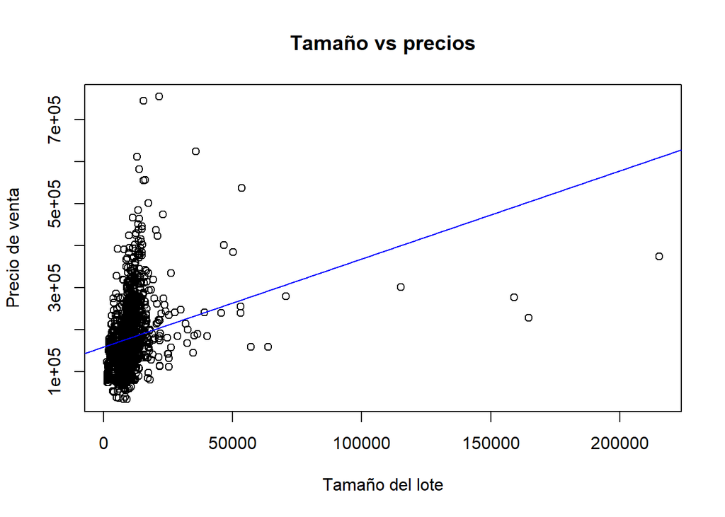

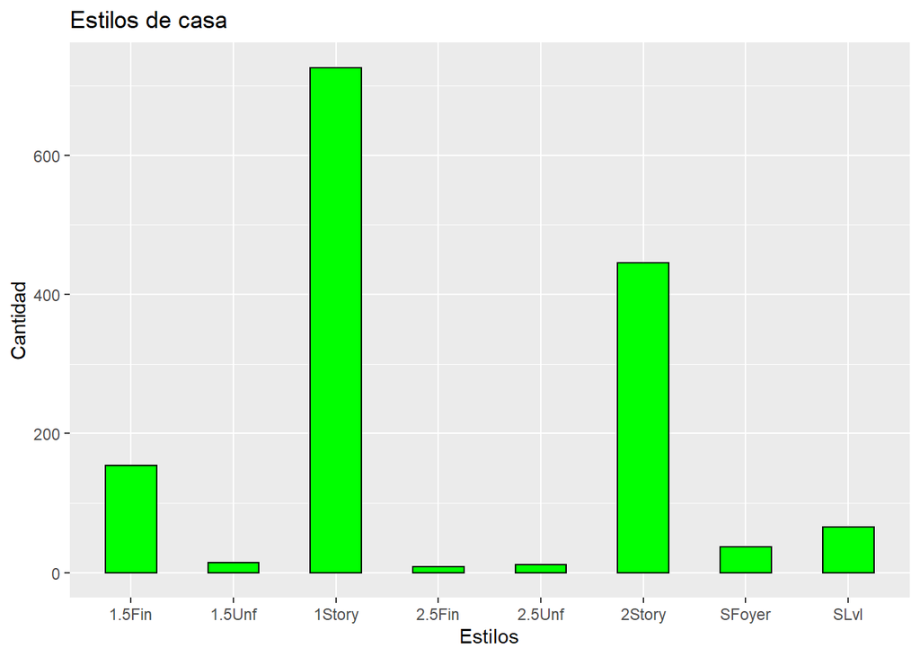

Las casas que predominan el mercado son las de un nivel.

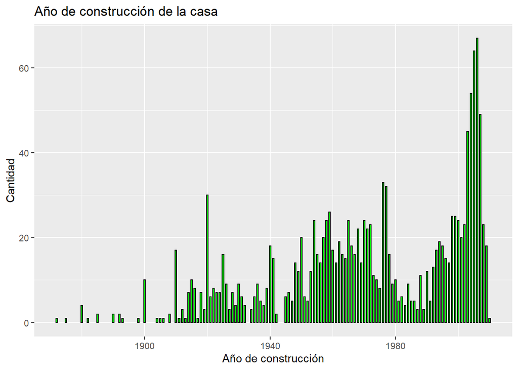

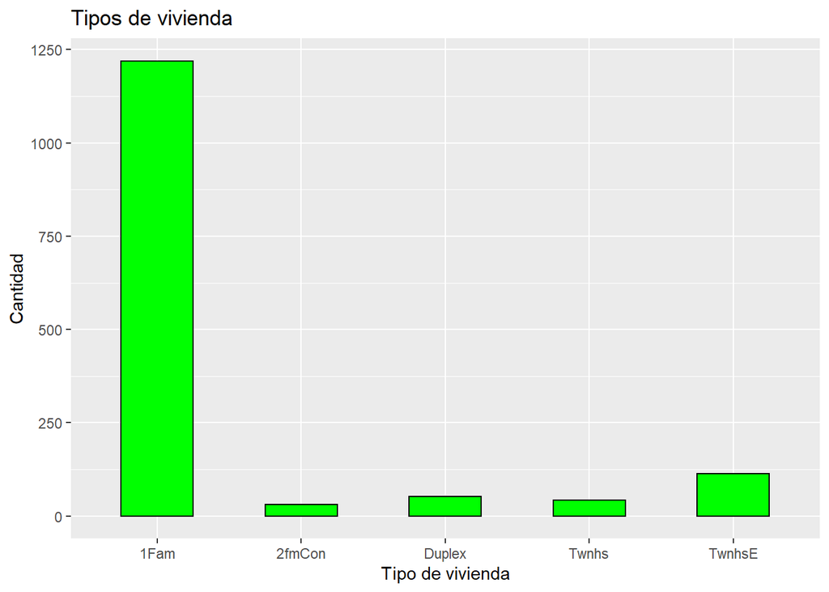

Los tipos de casas más populares, son aquellos que fueron diseñados para una sola familia.

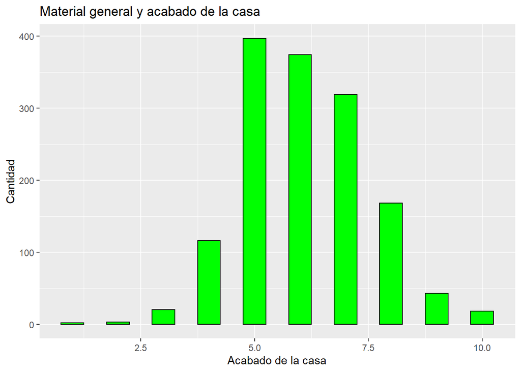

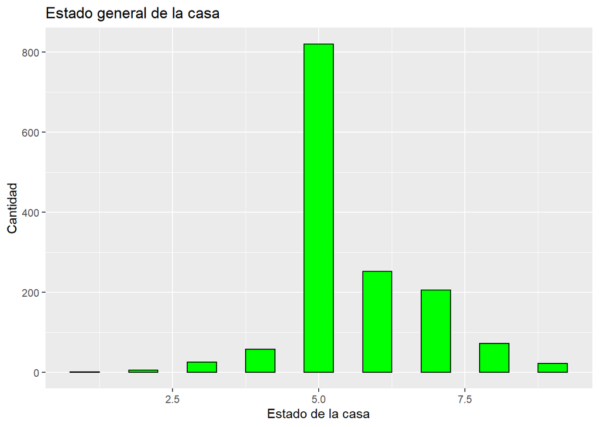

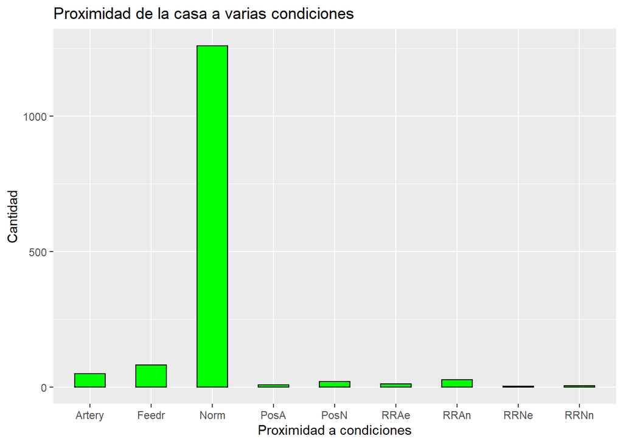

La proximidad más popular o que más se da es la normal.

### Clustering

Se trabajará con las siguientes variables: LotArea, overallQual, overallCond, yearBuilt,bedroomAbvGr, GarageArea, SalePrice pues ya que son de formato int, estos pueden ser clasificados y valorados.

Se calcula cuál es la cantidad ideal de clusters a utilizar.

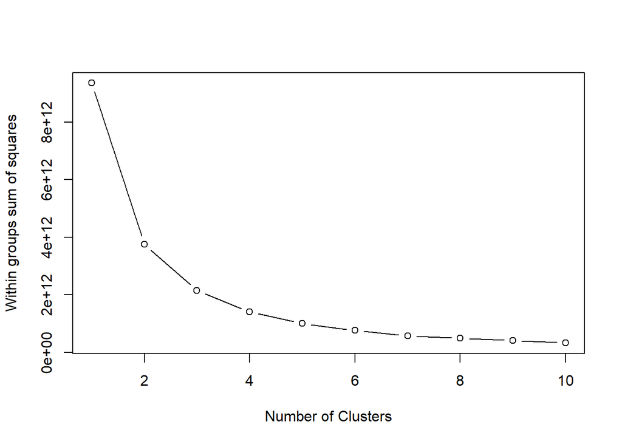

Como se puede observar en la gráfica de codo, la cantidad ideal de clusters es de 3.

#### Agrupamiento por medio de k-means

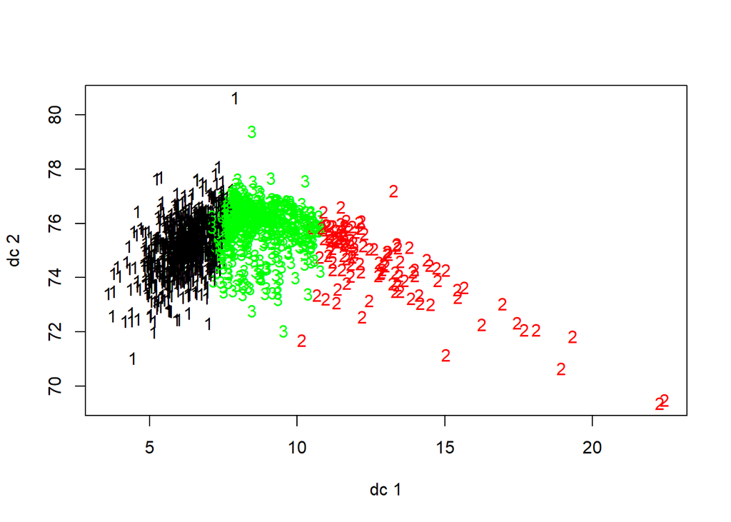

Con este algoritmo se puede ver que los datos se clasificaron en tres grupos, de los cuales uno está visualmente separado de los demás datos, y dos de estos están un poco más juntos.

#### Agrupamiento por medio de clustering jerárquico

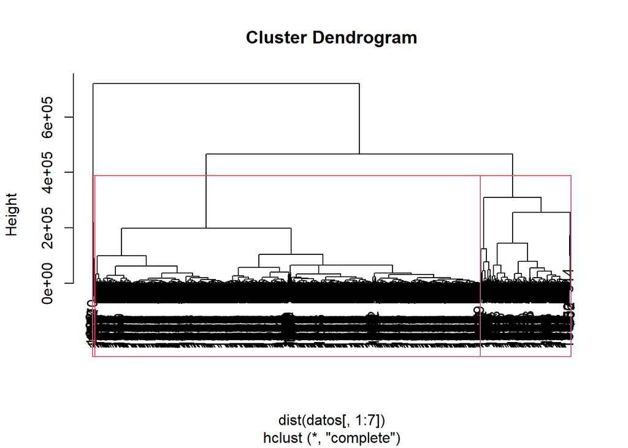

#### Calidad del agrupamiento

##### K-means

```
## [1] 0.5487144
```

##### Cluster jerárquico

```
## [1] 0.6258748
```

```
##     LotArea       OverallQual      OverallCond      YearBuilt
##  Min.   : 1300   Min.   : 1.000   Min.   :1.000   Min.   :1872
##  1st Qu.: 7200   1st Qu.: 5.000   1st Qu.:5.000   1st Qu.:1949
##  Median : 8960   Median : 6.000   Median :5.000   Median :1967
##  Mean   : 9299   Mean   : 5.678   Mean   :5.614   Mean   :1966
##  3rd Qu.:10792   3rd Qu.: 6.000   3rd Qu.:6.000   3rd Qu.:1994
##  Max.   :63887   Max.   :10.000   Max.   :9.000   Max.   :2009
##   BedroomAbvGr     GarageArea       SalePrice          grupo          gruposHC
##  Min.   :0.000   Min.   :   0.0   Min.   : 34900   Min.   :1.000   Min.   :1
##  1st Qu.:2.000   1st Qu.: 297.0   1st Qu.:124000   1st Qu.:1.000   1st Qu.:1
##  Median :3.000   Median : 440.0   Median :147000   Median :1.000   Median :1
##  Mean   :2.826   Mean   : 419.9   Mean   :150516   Mean   :1.628   Mean   :1
##  3rd Qu.:3.000   3rd Qu.: 528.0   3rd Qu.:179783   3rd Qu.:3.000   3rd Qu.:1
##  Max.   :8.000   Max.   :1418.0   Max.   :232600   Max.   :3.000   Max.   :1
```

```
##     LotArea        OverallQual      OverallCond      YearBuilt
##  Min.   :  3196   Min.   : 4.000   Min.   :2.000   Min.   :1880
##  1st Qu.: 10120   1st Qu.: 7.000   1st Qu.:5.000   1st Qu.:1992
##  Median : 11839   Median : 8.000   Median :5.000   Median :2003
##  Mean   : 15319   Mean   : 7.791   Mean   :5.422   Mean   :1993
##  3rd Qu.: 14230   3rd Qu.: 8.000   3rd Qu.:5.000   3rd Qu.:2006
##  Max.   :215245   Max.   :10.000   Max.   :9.000   Max.   :2010
##   BedroomAbvGr     GarageArea       SalePrice          grupo          gruposHC
##  Min.   :0.000   Min.   : 180.0   Min.   :228950   Min.   :2.000   Min.   :2
##  1st Qu.:3.000   1st Qu.: 552.0   1st Qu.:251000   1st Qu.:2.000   1st Qu.:2
##  Median :3.000   Median : 683.0   Median :278000   Median :3.000   Median :2
##  Mean   :3.022   Mean   : 688.3   Mean   :297184   Mean   :2.599   Mean   :2
##  3rd Qu.:4.000   3rd Qu.: 834.0   3rd Qu.:325000   3rd Qu.:3.000   3rd Qu.:2
##  Max.   :5.000   Max.   :1390.0   Max.   :501837   Max.   :3.000   Max.   :2
```

```
##     LotArea       OverallQual      OverallCond      YearBuilt     BedroomAbvGr
##  Min.   :12919   Min.   : 8.000   Min.   :5.000   Min.   :1994   Min.   :2.0
##  1st Qu.:15046   1st Qu.: 9.000   1st Qu.:5.000   1st Qu.:1996   1st Qu.:3.5
##  Median :15840   Median : 9.500   Median :5.000   Median :2004   Median :4.0
##  Mean   :23090   Mean   : 9.375   Mean   :5.125   Mean   :2002   Mean   :3.5
##  3rd Qu.:25091   3rd Qu.:10.000   3rd Qu.:5.000   3rd Qu.:2008   3rd Qu.:4.0
##  Max.   :53504   Max.   :10.000   Max.   :6.000   Max.   :2009   Max.   :4.0
##    GarageArea       SalePrice          grupo      gruposHC
##  Min.   : 672.0   Min.   :538000   Min.   :2   Min.   :3
##  1st Qu.: 784.2   1st Qu.:556186   1st Qu.:2   1st Qu.:3
##  Median : 816.5   Median :597295   Median :2   Median :3
##  Mean   : 815.1   Mean   :621146   Mean   :2   Mean   :3
##  3rd Qu.: 834.2   3rd Qu.:655000   3rd Qu.:2   3rd Qu.:3
##  Max.   :1020.0   Max.   :755000   Max.   :2   Max.   :3
```

Al realizar la agrupación por clusters, se puede ver que la división más obvia es por precio de venta. Dados los rangos de precio vistos en los resúmenes de los grupos, podemos establecer cuáles son los rangos para determinar si una casa es económica, intermedia o cara. Si el precio es menor o igual a 232,600, entonces es una casa económica. Si el precio se encuentra entre 232,601 y 501,837, entonces será una casa intermedia. Y si el precio es mayor a 501,838, entonces será una casa cara.

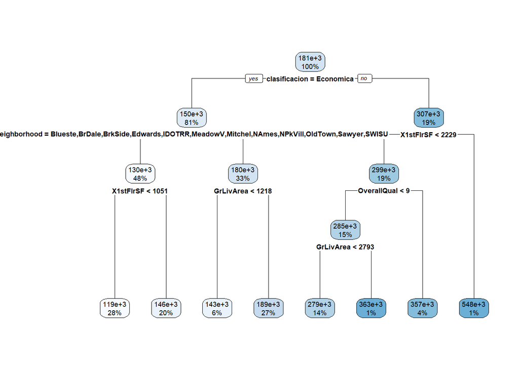